# Project 1 Part B

John Kellogg

3/28/2021

## Part B - Forecasting Power

### Assignment Question

Part B consists of a simple dataset of residential power usage for January 1998 until December 2013. Your assignment is to model these data and a monthly forecast for 2014. The data is given in a single file. The variable ‘KWH’ is power consumption in Kilowatt hours, the rest is straight forward.

### Data Management

```r
data_raw_b <- read_excel ('./data/ResidentialCustomerForecastLoad-624.xlsx', col_names = TRUE)%>%
  rename(DATE = 'YYYY-MMM')%>%
  mutate(DATE=as_date(paste(DATE, '01', sep='-'), format='%Y-%b-%d', tz='UTC'))
```

```r
summary(data_raw_b)
```

```
##   CaseSequence        DATE                 KWH
##  Min.   :733.0   Min.   :1998-01-01   Min.   :  770523
##  1st Qu.:780.8   1st Qu.:2001-12-24   1st Qu.: 5429912
##  Median :828.5   Median :2005-12-16   Median : 6283324
##  Mean   :828.5   Mean   :2005-12-15   Mean   : 6502475
##  3rd Qu.:876.2   3rd Qu.:2009-12-08   3rd Qu.: 7620524
##  Max.   :924.0   Max.   :2013-12-01   Max.   :10655730
##                                       NA's   :1
```

- We need to check for outliers as there is a large jump from the min to the 1st Q.
- There is a single NA value
  - k-nearest neighbor will be used again

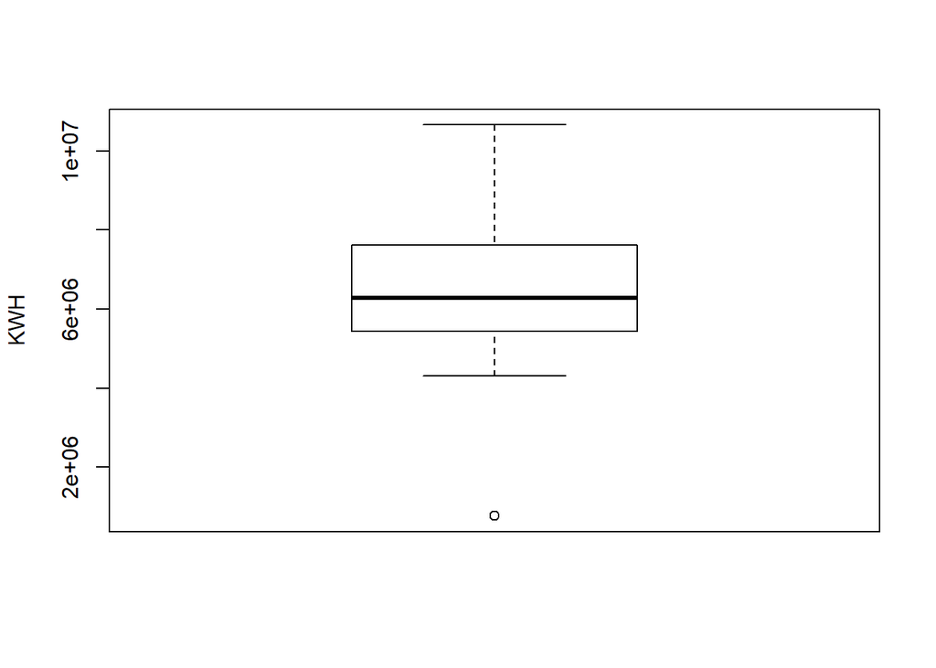

```r
boxplot(data_raw_b$KWH,
        ylab = "KWH")
```

```r
out <- boxplot.stats(data_raw_b$KWH)$out
out
```

```
## [1] 770523
```

- We do have an outlier which needs to be adjusted.
- I will zero out the value and apply the same k-nearest neighbor as with the other NA value with a 5 level Weighted moving average..

```r
data_raw_b <- data_raw_b%>%
  mutate(KWH = na_if(KWH, out))
```

```r
data_raw_b$KWH <- na_ma(data_raw_b$KWH, k = 5, weighting = "simple")
```

```r
summary(data_raw_b)
```

```
##   CaseSequence        DATE                 KWH
##  Min.   :733.0   Min.   :1998-01-01   Min.   : 4313019
##  1st Qu.:780.8   1st Qu.:2001-12-24   1st Qu.: 5443502
##  Median :828.5   Median :2005-12-16   Median : 6339797
##  Mean   :828.5   Mean   :2005-12-15   Mean   : 6531803
##  3rd Qu.:876.2   3rd Qu.:2009-12-08   3rd Qu.: 7608792
##  Max.   :924.0   Max.   :2013-12-01   Max.   :10655730
```

- The data now looks clean and ready for transforms

### Data Transforms

```r
pwr <- data_raw_b
tspwr <- ts(pwr$KWH, frequency = 12, start = c(1998,1))
```

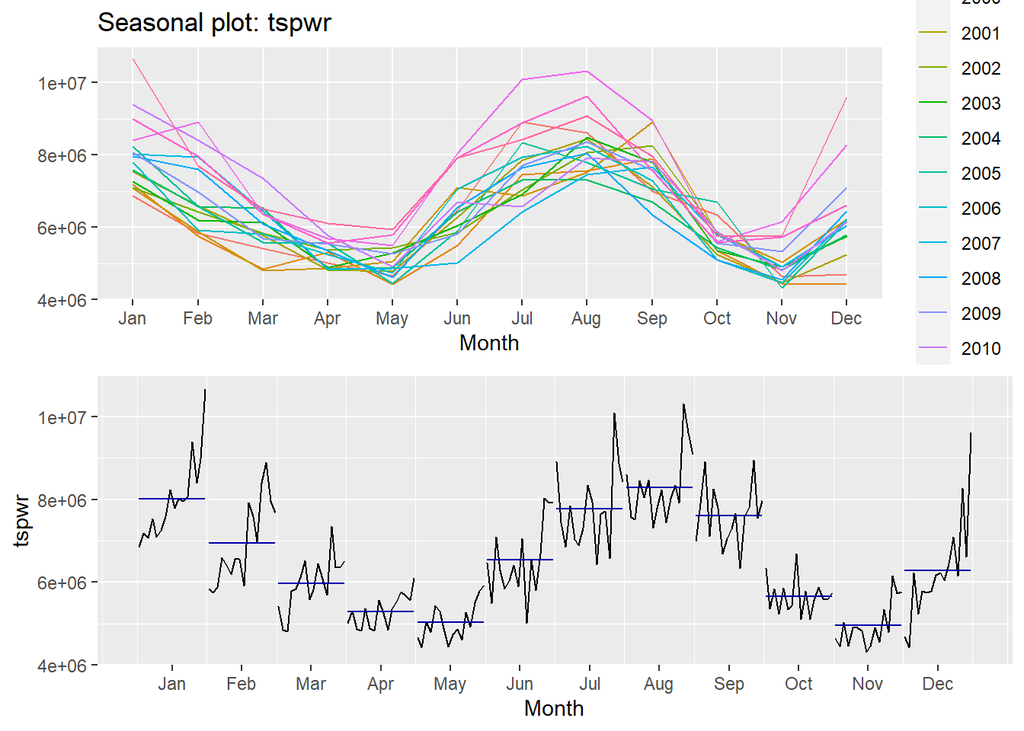

```r
grid.arrange(nrow=2,
  ggseasonplot(tspwr),
  ggsubseriesplot(tspwr))
```

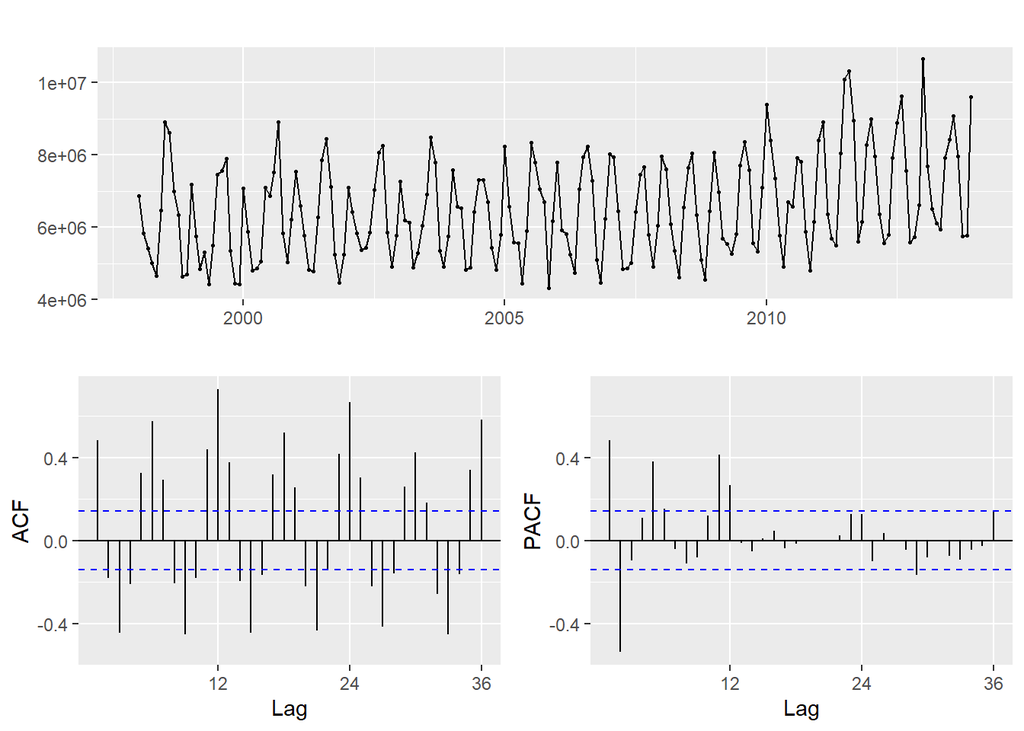

```r
ggtsdisplay(tspwr)
```

#### Box-Cox Transform

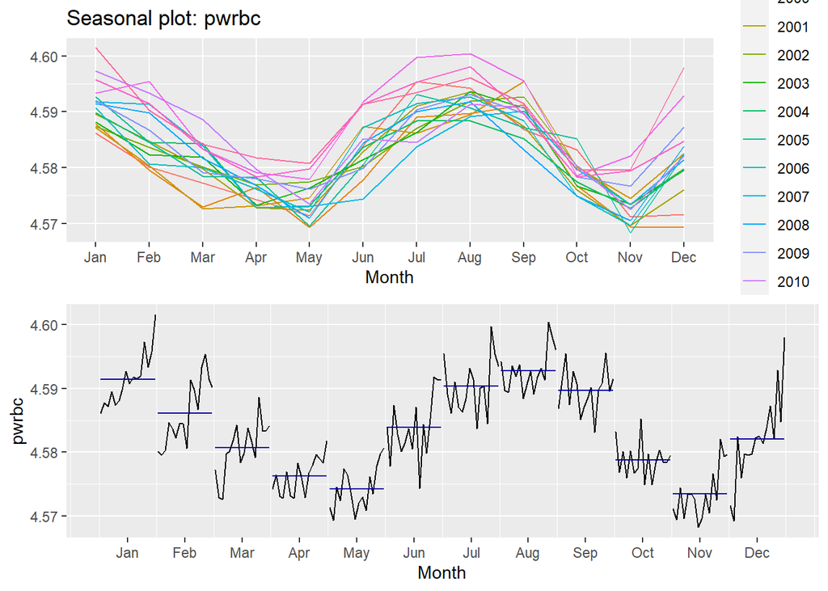

```r
pwr_lambda <- BoxCox.lambda(tspwr)
pwrbc <- BoxCox(tspwr, lambda = pwr_lambda)

grid.arrange(nrow=2,
  ggseasonplot(pwrbc),
  ggsubseriesplot(pwrbc))
```

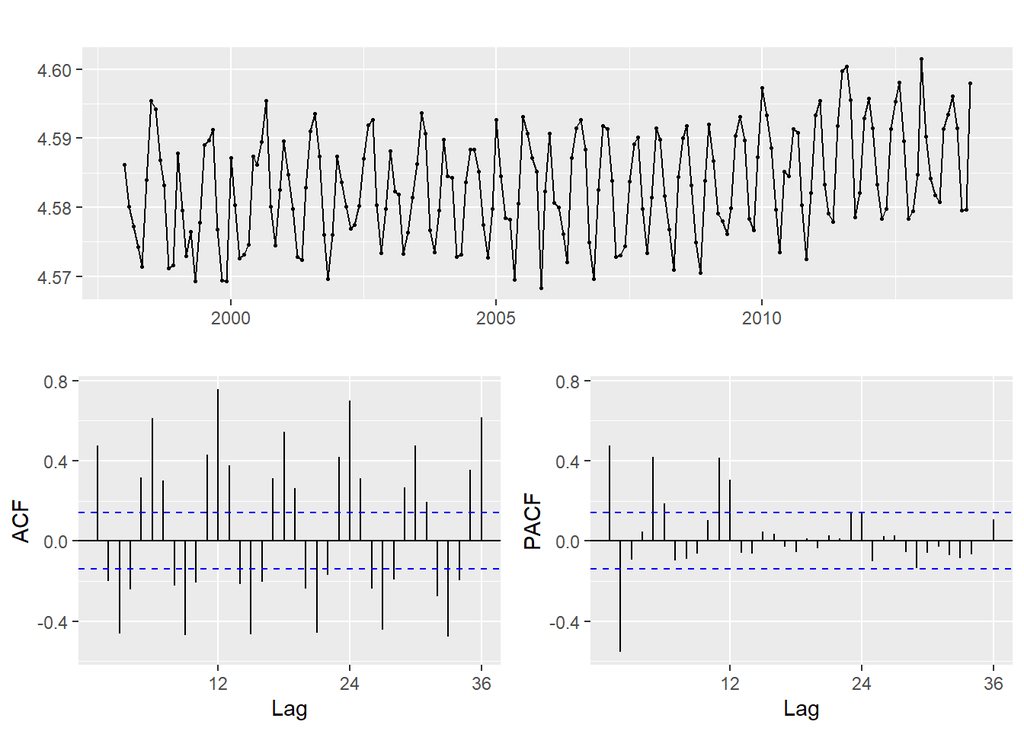

```r
ggtsdisplay(pwrbc)
```

```r
pwrbc %>% ur.kpss() %>% summary
```

```
##
## #######################
## # KPSS Unit Root Test #
## #######################
##
## Test is of type: mu with 4 lags.
##
## Value of test-statistic is: 1.595
##
## Critical value for a significance level of:
##                 10pct  5pct 2.5pct  1pct
## critical values 0.347 0.463  0.574 0.739
```

```r
ndiffs(tspwr)
```

```
## [1] 1
```

```r
ndiffs(pwrbc)
```

```
## [1] 1
```

- I am not seeing a major change in the data using a Box-Cox transform.
- I do see both formats still require at least one diff.
- The Test Statistic is very high

#### No Box-Cox with a single Diff

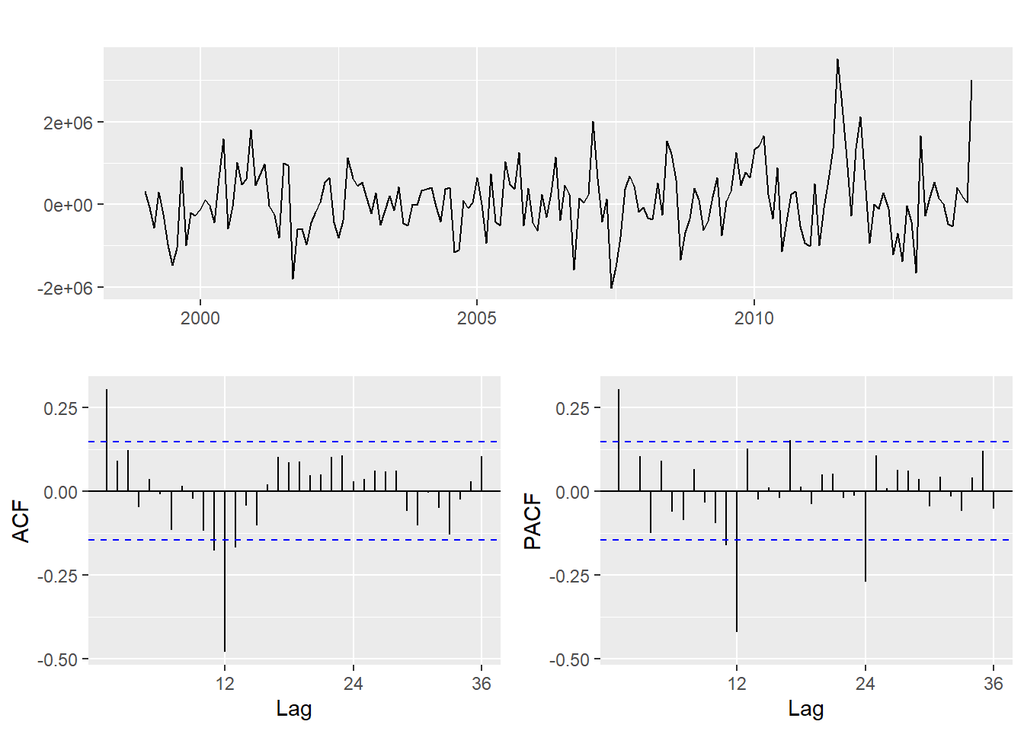

```r
ggtsdisplay(diff(tspwr, 12), points = FALSE)
```

```r
tspwr %>% diff %>% ur.kpss() %>% summary
```

```
##
## #######################
## # KPSS Unit Root Test #
## #######################
##
## Test is of type: mu with 4 lags.
##
## Value of test-statistic is: 0.0471
##
## Critical value for a significance level of:
##                 10pct  5pct 2.5pct  1pct
## critical values 0.347 0.463  0.574 0.739
```

#### Box-Cox with a single Diff

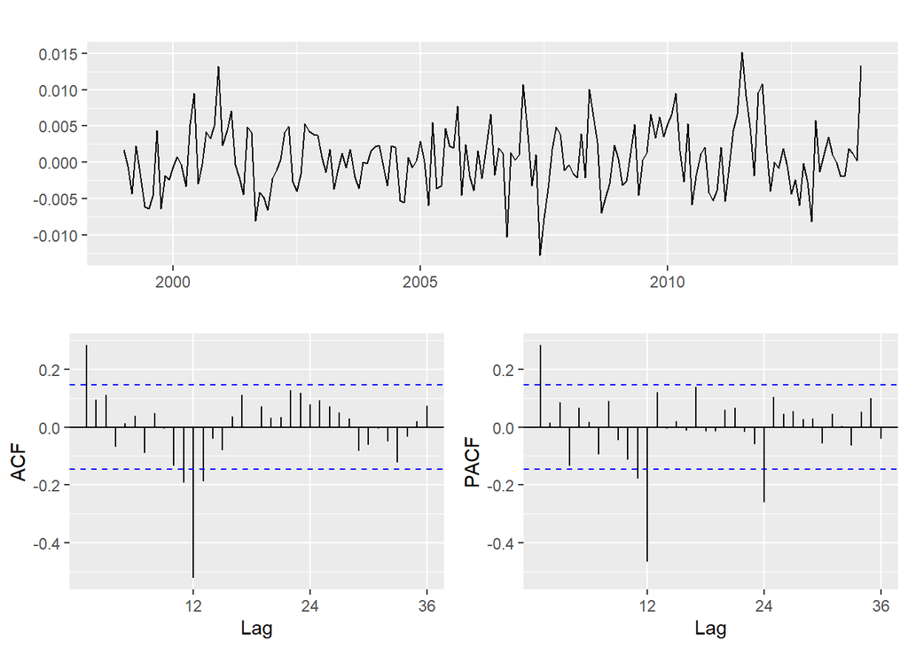

```r
ggtsdisplay(diff(pwrbc, 12), points = FALSE)
```

```r
pwrbc %>% diff %>% ur.kpss() %>% summary
```

```
##
## #######################
## # KPSS Unit Root Test #
## #######################
##
## Test is of type: mu with 4 lags.
##
## Value of test-statistic is: 0.0414
##
## Critical value for a significance level of:
##                 10pct  5pct 2.5pct  1pct
## critical values 0.347 0.463  0.574 0.739
```

- I think my final choice is to use the non Box-Cox data set going forward. I am not seeing enough justification to use the transform.
- The Lag of 12 does seem to be appropriate to the set.
- An MA term seems appropriate as there is 2 sets of decreasing lags at multiple of 12

```r
pwr_model <- Arima(tspwr, order = c(1,1,2), seasonal=c(1,1,2))
summary(pwr_model)
```

```
## Series: tspwr
## ARIMA(1,1,2)(1,1,2)[12]
##
## Coefficients:
##           ar1      ma1      ma2    sar1     sma1    sma2
##       -0.4594  -0.2116  -0.6683  0.1912  -1.0568  0.3482
## s.e.   0.2201   0.1826   0.1594  0.3456   0.3326  0.2376
##
## sigma^2 estimated as 4.089e+11:  log likelihood=-2650.19
## AIC=5314.39   AICc=5315.04   BIC=5336.7
##
## Training set error measures:
##                    ME     RMSE      MAE        MPE     MAPE      MASE
## Training set 42101.78 607001.7 449961.1 0.04052391 6.793162 0.7087288
##                    ACF1
## Training set 0.02217025
```

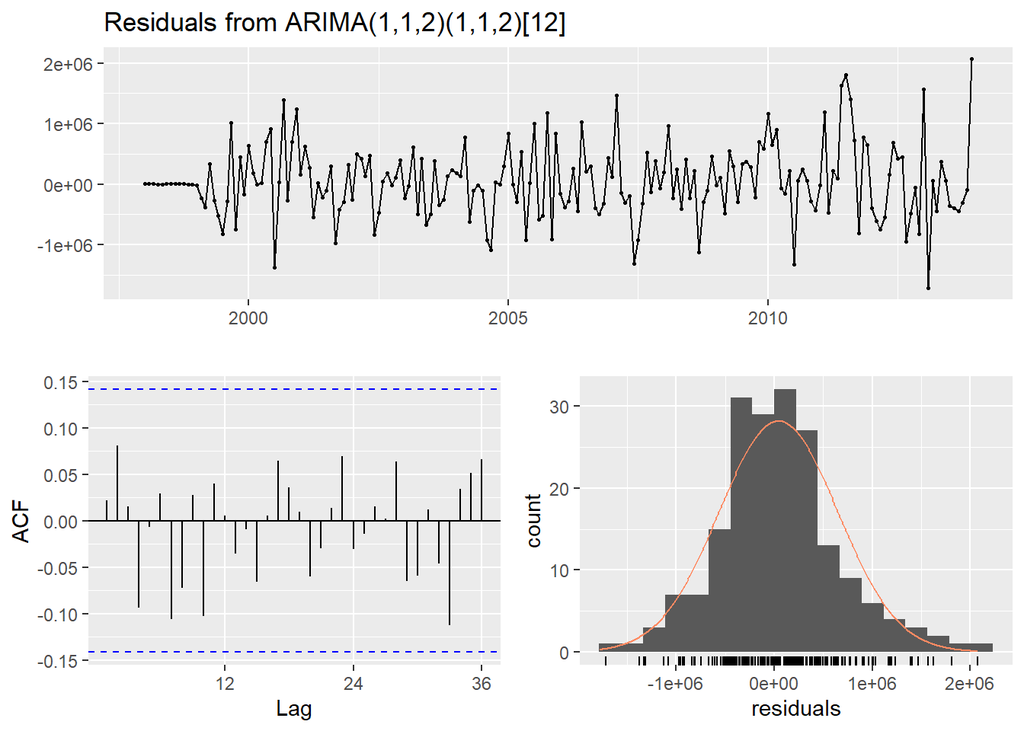

```
##
##  Ljung-Box test
##
## data:  Residuals from ARIMA(1,1,2)(1,1,2)[12]
## Q* = 14.027, df = 18, p-value = 0.7273
##
## Model df: 6.   Total lags used: 24
```

```r
checkresiduals(pwr_model)
```

```r
auto_model <- auto.arima(tspwr, d=1, approximation = FALSE)
summary(auto_model)
```

```
## Series: tspwr
## ARIMA(1,1,2)(2,1,0)[12]
##
## Coefficients:
##           ar1      ma1      ma2     sar1     sar2
##       -0.5466  -0.1434  -0.7342  -0.8017  -0.4634
## s.e.   0.1837   0.1480   0.1244   0.0753   0.0761
##
## sigma^2 estimated as 4.037e+11:  log likelihood=-2649.66
## AIC=5311.32   AICc=5311.81   BIC=5330.44
##
## Training set error measures:
##                    ME     RMSE      MAE          MPE     MAPE      MASE
## Training set 36857.45 604849.7 445553.1 -0.009880902 6.736162 0.7017858
##                    ACF1
## Training set 0.02896049
```

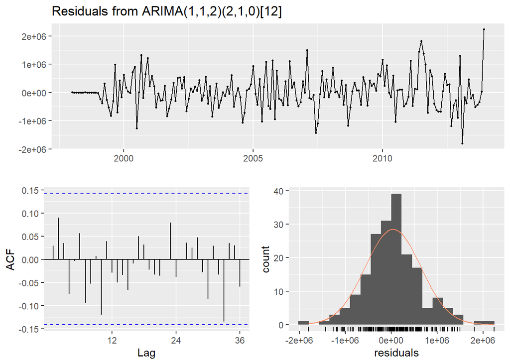

```
##
##  Ljung-Box test
##
## data:  Residuals from ARIMA(1,1,2)(2,1,0)[12]
## Q* = 14.373, df = 19, p-value = 0.7615
##
## Model df: 5.   Total lags used: 24
```

```r
checkresiduals(auto_model)
```

- My model seems very close to the auto model
- For the sake of this project, I will continue with my model as there is not enough significant difference between the two to justify the swap.

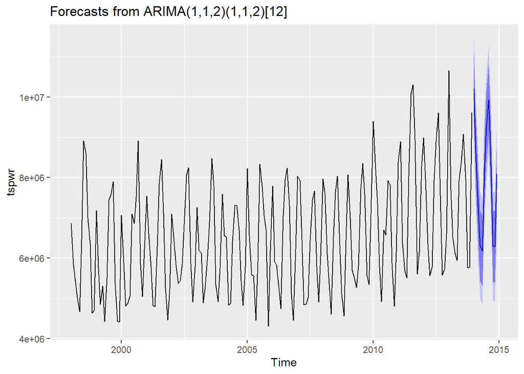

```r
pwr_forecast <- forecast(pwr_model, h = 12)
autoplot(pwr_forecast)
```

```r
signif(pwr_forecast$mean/1000000,3)
```

```
##        Jan   Feb   Mar   Apr   May   Jun   Jul   Aug   Sep   Oct   Nov
## 2014 10.20  8.61  7.26  6.31  6.18  8.15  9.25  9.93  8.66  6.30  6.28
##        Dec
## 2014  8.09
```

```r
export <- pwr_forecast$mean
write.csv(export, "Power Forecasts.csv")
```